# R Notebook

```r
library(dplyr)
library(stringr)
library(tidytext)
library(gsubfn)
```

```r
library(ggplot2)
```

Which injuries are most common in the NFL? We will present summary statistics and graphs demonstrating injury frequency Will include specific injuries along with injuries categorized by body part (knee, head, shoulder, etc.)

Breakdown of injury composition by position

Create a Shiny app showing summary data Show a bar chart with the count and type of injuries Inputs: age range, team, position

Read in the data set

```r
injuries <- read.csv("C:/Users/wduff/OneDrive/School/Harvard/Fall2021/BST260/BST_260_project/Data/injuries_only.csv")
```

```r
head(injuries)
```

|  | X | name | full_team | team | year | games_in_season | num_games_missing | num_games_injured | injury_types | earliest_injury | latest_injury | position_id | NFL_draft_year | NFL_draft_round | NFL_draft_rank | height_inches | weight_pounds | birthdate | forty_yd | three_cone | bench | broad_jump | combine_height | combine_weight | shuttle | vertical | game_starter |
| --- | --- | --- | --- | --- | --- | --- | --- | --- | --- | --- | --- | --- | --- | --- | --- | --- | --- | --- | --- | --- | --- | --- | --- | --- | --- | --- | --- |
| 1 | 18 | Michael Adams | Arizona Cardinals | crd | 2009 | 18 | 0 | 3 | hamstring | 8 | 14 | DEF | NA | NA | NA | 68 | 178 | 1985-06-17 | NA | NA | NA | NA | NA | NA | NA | NA | 0 |
| 2 | 19 | Jason Banks | Arizona Cardinals | crd | 2009 | 18 | 2 | 2 | ankle | 17 | 18 | DEF | NA | NA | NA | 77 | 300 | 1985-05-08 | NA | NA | NA | NA | NA | NA | NA | NA | 0 |
| 3 | 36 | Bertrand Berry | Arizona Cardinals | crd | 2009 | 18 | 0 | 1 | illness | 13 | 13 | DEF | 1997 | 3 | 86 | 75 | 254 | 1975-08-15 | NA | NA | NA | NA | NA | NA | NA | NA | 0 |
| 4 | 51 | Anquan Boldin | Arizona Cardinals | crd | 2009 | 18 | 3 | 8 | hamstring ankle ankle/knee | 1 | 18 | WR | 2003 | 2 | 54 | 73 | 220 | 1980-10-03 | 4.72 | 7.35 | 0 | 114 | 73 | 216 | 4.33 | 33.5 | 1 |
| 5 | 69 | Alan Branch | Arizona Cardinals | crd | 2009 | 18 | 0 | 1 | ankle | 13 | 13 | DEF | 2007 | 2 | 33 | 78 | 350 | 1984-12-29 | 5.07 | 0.00 | 33 | 107 | 78 | 324 | 0.00 | 27.5 | 0 |
| 6 | 86 | Steve Breaston | Arizona Cardinals | crd | 2009 | 18 | 1 | 11 | knee | 1 | 11 | WR | 2007 | 5 | 142 | 73 | 175 | 1983-08-20 | 4.46 | 6.90 | 0 | 124 | 72 | 193 | 4.29 | 33.0 | 1 |

```r
dim(injuries)
```

```
## [1] 17362    27
```

```r
injuries
```

[output not shown]

[output cut: 9990 more lines]

Make all injury types lower case to help with string processing

```r
injuries <- injuries %>% mutate(injury_types = tolower(injury_types))
```

There are a lot of different levels in the injury types, so we are going to look at the most common ones (specifically) and then we will look at injuries by parts of the body.

```r
head(levels(as.factor(injuries$injury_types)))
```

```
## [1] ""
## [2] "abdomen"
## [3] "abdomen  achilles"
## [4] "abdomen  back"
## [5] "abdomen  concussion hamstring shoulder"
## [6] "abdomen  concussion shoulder hand"
```

The parts of the body will be categorized as: Head, Shoulder, Upper Torso, Lower Torso, Internal, Arm, Hand, Leg and Foot. Each of these categories has the following injury type:

Head: concussion head neck eye ear chin migranes migrane jaw nose tooth stinger faciallaceration eyelid facial mouth nose throat seizure

Shoulder: shoulder clavicle collarbone leftshoulder rightshoulder joint shoulder scapula sternoclavicular

Upper Torso (includes internal injuries) : rib back pectoral/pec chest oblique lumbar core spine trapezius kidney lung heart abdomen abdominal solarplexus spleen hernia arrhythmia liver stomach appendix

Lower Torso: glute buttocks hip/righthip pelvis tailbone

Arm: arm/rightupperarm/forearm bicep/biceps elbow/rightelbow tricep/triceps

Hand: hand/righthand thumb/rightthumb finger/rightfinger wrist/rightwrist

Leg: hamstring/righthamstring knee/rightknee/acl/mcl/meniscus/bothknees thigh/rightthigh calf/rightcalf quadricep/rightquadricep/quad groin/rightgroin lowerlegtibia/fibula/shin/rightshin adductor contusion

Foot: foot/rightfoot ankle achilles toe/toes heel

Total injuries for each injury, categorized by body part

```r
# Head
concussion <- sum(str_detect(injuries$injury_types, pattern = "concussion"))
head <- sum(str_detect(injuries$injury_types, pattern = "head"))
neck <- sum(str_detect(injuries$injury_types, pattern = "neck"))
eye <- sum(str_detect(injuries$injury_types, pattern = "eye"))
ear <- sum(str_detect(injuries$injury_types, pattern = "ear"))
chin <- sum(str_detect(injuries$injury_types, pattern = "chin"))
migraine <- sum(str_detect(injuries$injury_types, pattern = "migraine|migraines"))
jaw <- sum(str_detect(injuries$injury_types, pattern = "jaw"))
nose <- sum(str_detect(injuries$injury_types, pattern = "nose"))
tooth <- sum(str_detect(injuries$injury_types, pattern = "tooth"))
stinger <- sum(str_detect(injuries$injury_types, pattern = "stinger"))
faciallaceration <- sum(str_detect(injuries$injury_types, pattern = "faciallaceration"))
eyelid <- sum(str_detect(injuries$injury_types, pattern = "eyelid"))
facial <- sum(str_detect(injuries$injury_types, pattern = "facial"))
mouth <- sum(str_detect(injuries$injury_types, pattern = "mouth"))
nose <- sum(str_detect(injuries$injury_types, pattern = "nose"))
throat <- sum(str_detect(injuries$injury_types, pattern = "throat"))
seizure <- sum(str_detect(injuries$injury_types, pattern = "seizure"))



individual_head <- c(concussion, head, neck, eye, ear, chin, migraine, jaw, nose, tooth, stinger, faciallaceration, eyelid, facial, mouth, nose, throat, seizure)
total_head <- concussion + head + neck + eye + ear + chin + migraine + jaw + nose + tooth + stinger + faciallaceration + eyelid + facial + mouth + nose + throat + seizure

total_head
```

```
## [1] 2488
```

```r
individual_head
```

```
##  [1] 1424  286  606   32   67    2    7    8    8    5   24    1    1    2    1
## [16]    8    5    1
```

We have a total of 2488 injuries for the head, with concussions being the leading injury

```r
# Shoulder

shoulder <- sum(str_detect(injuries$injury_types, pattern = "shoulder|leftshoulder|jointshoulder|rightshoulder"))
clavicle <- sum(str_detect(injuries$injury_types, pattern = "clavicle"))
collarbone <- sum(str_detect(injuries$injury_types, pattern = "collarbone"))
scapula <- sum(str_detect(injuries$injury_types, pattern = "scapula"))
sternoclavicular <- sum(str_detect(injuries$injury_types, pattern = "sternoclavicular"))


individual_shoulder <- c(shoulder, clavicle, collarbone, scapula, sternoclavicular)
total_shoulder <- shoulder + clavicle + collarbone + scapula + sternoclavicular


total_shoulder
```

```
## [1] 1980
```

```r
individual_shoulder
```

```
## [1] 1944    6   28    1    1
```

There are a total of 1980 overall shoulder injuries, with shoulder being the greatest injury type

```r
# Upper Torso

rib <- sum(str_detect(injuries$injury_types, pattern = "rib|ribs"))
back <- sum(str_detect(injuries$injury_types, pattern = "back"))
pectoral <- sum(str_detect(injuries$injury_types, pattern = "pectoral|pec"))
chest <- sum(str_detect(injuries$injury_types, pattern = "chest"))
oblique <- sum(str_detect(injuries$injury_types, pattern = "oblique"))
lumbar <- sum(str_detect(injuries$injury_types, pattern = "lumbar"))
core <- sum(str_detect(injuries$injury_types, pattern = "core"))
spine <- sum(str_detect(injuries$injury_types, pattern = "spine"))
trapezius <- sum(str_detect(injuries$injury_types, pattern = "trapezius"))
kidney <- sum(str_detect(injuries$injury_types, pattern = "kidney"))
lung <- sum(str_detect(injuries$injury_types, pattern = "lung"))
heart <- sum(str_detect(injuries$injury_types, pattern = "heart"))
abdominal <- sum(str_detect(injuries$injury_types, pattern = "abdomen|abdominal"))
solarplexus <- sum(str_detect(injuries$injury_types, pattern = "solarplexus"))
spleen <- sum(str_detect(injuries$injury_types, pattern = "spleen"))
hernia <- sum(str_detect(injuries$injury_types, pattern = "hernia"))
arrhythmia <- sum(str_detect(injuries$injury_types, pattern = "arrhythmia"))
liver <- sum(str_detect(injuries$injury_types, pattern = "liver"))
stomach <- sum(str_detect(injuries$injury_types, pattern = "stomach"))
appendix <- sum(str_detect(injuries$injury_types, pattern = "appendix"))


total_uppertorso <- rib + back + pectoral + chest + oblique + lumbar + core + spine + trapezius + kidney + lung + heart + abdominal + solarplexus + spleen + hernia + arrhythmia + liver + stomach + appendix
individual_uppertorso <- c(rib, back, pectoral, chest, oblique, lumbar, core, spine, trapezius, kidney, lung, heart, abdominal, solarplexus, spleen, hernia, arrhythmia, liver, stomach, appendix)

total_uppertorso
```

```
## [1] 2173
```

```r
individual_uppertorso
```

```
##  [1]  434 1107  112  249   33    1    6    5    1   10    8    5  176    1    3
## [16]   16    1    1    3    1
```

There are a total of 2,173 upper torso injuries, with back being the most frequent injury type

```r
# Lower Torso

glute <- sum(str_detect(injuries$injury_types, pattern = "glute|buttocks"))
hip <- sum(str_detect(injuries$injury_types, pattern = "hip|righthip|lefthip"))
pelvis <- sum(str_detect(injuries$injury_types, pattern = "pelvis"))
tailbone <- sum(str_detect(injuries$injury_types, pattern = "tailbone"))


total_lowertorso <- glute + hip + pelvis + tailbone
individual_lowertorso <- c(glute, hip, pelvis, tailbone)

total_lowertorso
```

```
## [1] 810
```

```r
individual_lowertorso
```

```
## [1]  17 780  10   3
```

There are a total of 810 lower torso injuries with hip injuries being the most frequent

```r
# Arm

arm <- sum(str_detect(injuries$injury_types, pattern = "arm|forearm|rightupperarm"))
elbow <- sum(str_detect(injuries$injury_types, pattern = "elbow|rightelbow|leftelbow"))
tricep <- sum(str_detect(injuries$injury_types, pattern = "tricep|triceps"))
bicep <- sum(str_detect(injuries$injury_types, pattern = "bicep|biceps"))



total_arm <- arm + elbow + tricep + bicep
individual_arm <- c(arm, elbow, tricep, bicep)

total_arm
```

```
## [1] 694
```

```r
individual_arm
```

```
## [1] 129 392  76  97
```

There are a total of 694 total arm injuries with elbow injuries being the most frequent

```r
# Hand

hand <- sum(str_detect(injuries$injury_types, pattern = "righthand|lefthand|hand"))
thumb <- sum(str_detect(injuries$injury_types, pattern = "thumb|rightthumb|leftthumb"))
finger <- sum(str_detect(injuries$injury_types, pattern = "finger|rightfinger|leftfinger"))
wrist <- sum(str_detect(injuries$injury_types, pattern = "wrist|rightwrist|leftwrist"))

total_hand <- hand + thumb + finger + wrist
individual_hand <- c(hand, thumb, finger, wrist)

total_hand
```

```
## [1] 1003
```

```r
individual_hand
```

```
## [1] 344 225 189 245
```

There is a total of 1003 hand injuries with overall hand injuries being the most frequent

```r
# Leg

hamstring <- sum(str_detect(injuries$injury_types, pattern = "hamstring|righthamstring|lefthamstring"))
knee <- sum(str_detect(injuries$injury_types, pattern = "knee|rightknee|leftknee|acl|mcl|meniscus|bothknees"))
thigh <- sum(str_detect(injuries$injury_types, pattern = "thigh|rightthigh|leftthigh"))
calf <- sum(str_detect(injuries$injury_types, pattern = "calf|leftcalf|rightcalf"))
quadricep <- sum(str_detect(injuries$injury_types, pattern = "quadricep|leftquadricep|rightquadricep|quad"))
groin <- sum(str_detect(injuries$injury_types, pattern = "groin|rightgroin|leftgroin"))
lowerleg <- sum(str_detect(injuries$injury_types, pattern = "tibia|fibula|lowerleg|shin|rightshin|leftshin"))
adductor <- sum(str_detect(injuries$injury_types, pattern = "adductor"))
contusion <- sum(str_detect(injuries$injury_types, pattern = "contusion"))



total_leg <- hamstring + knee + thigh + calf + quadricep + groin + lowerleg + adductor + contusion
individual_leg <- c(hamstring, knee, thigh, calf, quadricep, groin, lowerleg, adductor, contusion)

total_leg
```

```
## [1] 9212
```

```r
individual_leg
```

```
## [1] 2152 4298  417  676  453 1044  170    1    1
```

There were a total of 9212 leg injuries with knee injuries being the most frequent

```r
# Foot

foot <- sum(str_detect(injuries$injury_types, pattern = "foot|rightfoot|leftfoot"))
ankle <- sum(str_detect(injuries$injury_types, pattern = "ankle|rightankle|leftankle"))
achilles <- sum(str_detect(injuries$injury_types, pattern = "achilles"))
toe <- sum(str_detect(injuries$injury_types, pattern = "toe|toes"))
heel <- sum(str_detect(injuries$injury_types, pattern = "heel"))

total_foot <- foot + ankle + achilles + toe + heel
individual_foot <- c(foot, ankle, achilles, toe, heel)


total_foot
```

```
## [1] 4942
```

```r
individual_foot
```

```
## [1] 1135 3127  239  400   41
```

There are a total of 4942 foot injuries with ankle injuries being the most frequent

Creating a new data frame including injury types, counts and body part

```r
injurytype <- c("concussion", "head", "neck", "eye", 'ear', 'chin', 'migraine', 'jaw', 'nose', 'tooth', "stinger", "faciallaceration", "eyelid", "facial", "mouth", "nose", "throat", "seizure",
                "shoulder", "clavicle", "collarbone", "scapula", "sternoclavicular",
                'rib', 'back', 'pectoral', 'chest', 'oblique', 'lumbar', "core", "spine", 'trapezius', 'kidney', 'lung', 'heart', 'abdominal', 'solarplexus', 'spleen', 'hernia', "arrhythmia", "liver", "stomach", "appendix",
                'glute', 'hip', 'pelvis', "tailbone",
                'arm', 'elbow', 'tricep', "bicep",
                'hand', 'thumb', 'finger', 'wrist',
                'hamstring', 'knee', 'thigh', 'calf', 'quadricep',  'groin', 'lowerleg', 'adductor', "contusion",
                'foot', 'ankle', 'achilles', 'toe', 'heel')

count <- c(concussion, head, neck, eye, ear, chin, migraine, jaw, nose, tooth, stinger, faciallaceration, eyelid, facial, mouth, nose, throat, seizure,
           shoulder, clavicle, collarbone, scapula, sternoclavicular,
           rib, back, pectoral, chest, oblique, lumbar, core, spine, trapezius, kidney, lung, heart, abdominal, solarplexus, spleen, hernia, arrhythmia, liver, stomach, appendix,
           glute, hip, pelvis, tailbone,
           arm, elbow, tricep, bicep,
           hand, thumb, finger, wrist,
           hamstring, knee, thigh, calf, quadricep, groin, lowerleg, adductor, contusion,
           foot, ankle, achilles, toe, heel)

bodypart <- c(rep("Head", length(individual_head)),
              rep("Shoulder", length(individual_shoulder)),
              rep("Upper Torso", length(individual_uppertorso)),
              rep("Lower Torso", length(individual_lowertorso)),
              rep("Arm", length(individual_arm)),
              rep("Hand", length(individual_hand)),
              rep("Leg", length(individual_leg)),
              rep("Foot", length(individual_foot))
              )

injury_count <- data.frame(injurytype, count, bodypart)

injury_count %>% arrange(desc(count))
```

| injurytype | count | bodypart |
| --- | --- | --- |
| knee | 4298 | Leg |
| ankle | 3127 | Foot |
| hamstring | 2152 | Leg |
| shoulder | 1944 | Shoulder |
| concussion | 1424 | Head |
| foot | 1135 | Foot |
| back | 1107 | Upper Torso |
| groin | 1044 | Leg |
| hip | 780 | Lower Torso |
| calf | 676 | Leg |

[output cut: 59 more lines]

Let’s look at the distribution of each specific injury

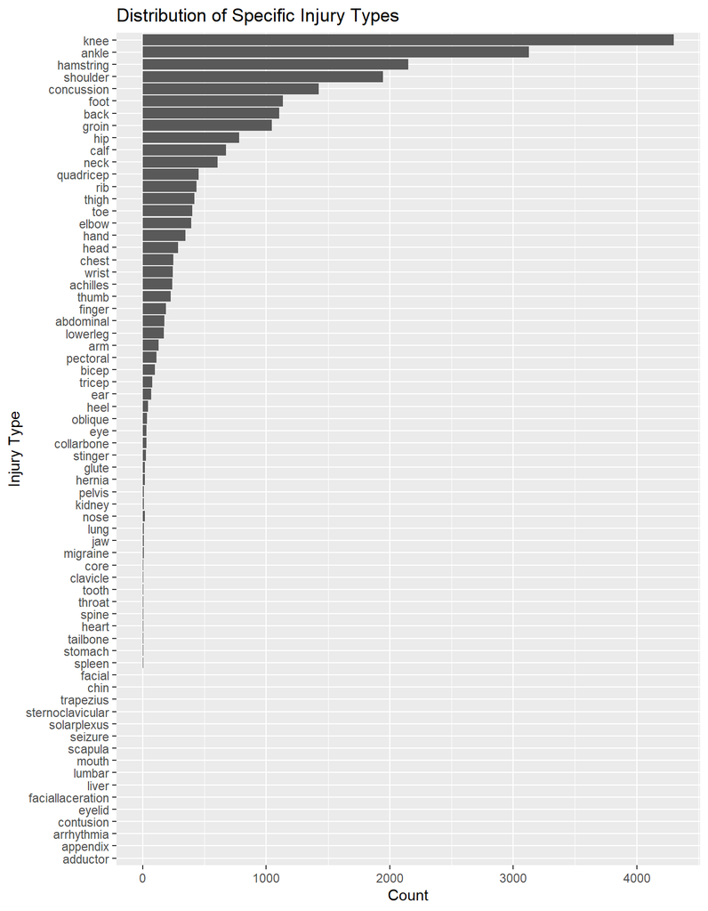

```r
injury_count %>%
  mutate(injurytype = reorder_within(injurytype,count, bodypart)) %>%
  ggplot(aes(y=injurytype, x=count)) +
  geom_col()+
  scale_y_reordered() +
  xlab("Count") +
  ylab("Injury Type") +
  ggtitle("Distribution of Specific Injury Types")
```

We see that injuries towards the bottom are not that frequent. Let’s group the injuries together based on where they are in the body and look at a more general distriubtion instead.